# R-Based Forecasting Project Using TÜİK Data

Hüseyin Berat Özen

2026-05-29

# 1 Project Overview

This project develops a reproducible R-based forecasting workflow using a TÜİK time series. The selected variable is the monthly rate of change in the Agricultural Products Producer Price Index. The goal is to compare alternative forecasting methods and forecast the next monthly period after the latest available TÜİK observation.

# 2 Student Information

```r
source_info <- project_source_info()
student_info <- data.frame(
  Field = c("Student Name", "Student Number"),
  Value = c(source_info$student_name, source_info$student_number)
)
student_info
```

```
##            Field              Value
## 1   Student Name Hüseyin Berat Özen
## 2 Student Number          138722005
```

# 3 TÜİK Data Source Information

```r
source_table <- data.frame(
  Field = c(
    "TÜİK Data Set Name",
    "TÜİK Theme / Category",
    "TÜİK Table Name",
    "tuikr Dataflow ID",
    "Selected Variable",
    "Data Frequency",
    "Data Access Date"
  ),
  Value = c(
    source_info$dataset_name,
    source_info$theme,
    source_info$table_name,
    source_info$dataflow_id,
    source_info$selected_variable,
    source_info$frequency,
    source_info$access_date
  )
)
source_table
```

```
##                   Field
## 1    TÜİK Data Set Name
## 2 TÜİK Theme / Category
## 3       TÜİK Table Name
## 4     tuikr Dataflow ID
## 5     Selected Variable
## 6        Data Frequency
## 7      Data Access Date
##                                                                          Value
## 1                                   Agricultural Products Producer Price Index
## 2                                                             Price Statistics
## 3 Producer Price Index of Agricultural Products and Rates of Change [2020=100]
## 4                                      TR,DF_TARIM_URUNLERI_UFE_DEGISIM_V1,1.0
## 5                                    Change compared to the previous month (%)
## 6                                                                      Monthly
## 7                                                                   2026-05-29
```

# 4 Data Access Through `tuikr`

The dataflow is first verified through `tuikr::statistical_tables(theme = 6)`. On this machine, `tuikr::statistical_data()` returns HTTP 401 for SDMX downloads, so the notebook uses the verified dataflow ID to retrieve the same live Data Browser JSON in R. This R-based fallback was approved for the course after the SDMX 401 issue was documented. No manually downloaded or manually edited data file is used.

```r
import_result <- fetch_selected_series()

verified_table <- import_result$verified_table
series <- import_result$series

verified_table
```

```
## # A tibble: 1 × 6
##   theme_name       theme_id table_name           node_type dataflow_id table_url
##   <chr>            <chr>    <chr>                <chr>     <chr>       <chr>
## 1 Price Statistics 6        Producer Price Inde… dataflow  TR,DF_TARI… https://…
```

```r
latest_observation <- max(series$period)
forecast_target_period <- next_month_period(latest_observation)

coverage_table <- data.frame(
  Field = c("Time Coverage", "Latest Available Observation", "Forecast Target Period", "Number of Observations"),
  Value = c(
    paste(min(series$period), "/", max(series$period)),
    latest_observation,
    forecast_target_period,
    nrow(series)
  )
)
coverage_table
```

```
##                          Field             Value
## 1                Time Coverage 2010-02 / 2026-04
## 2 Latest Available Observation           2026-04
## 3       Forecast Target Period           2026-05
## 4       Number of Observations               195
```

# 5 Use of TÜİK Data in R

The imported data are filtered in R to the total Agricultural Products Producer Price Index series for Türkiye, monthly frequency, base year 2020, and the variable “Change compared to the previous month (%)”. The period column is converted to a monthly date and observations are sorted chronologically.

```r
head(series, 10)
```

```
## # A tibble: 10 × 3
##    period  date       value
##    <chr>   <date>     <dbl>
##  1 2010-02 2010-02-01  4.04
##  2 2010-03 2010-03-01  2.79
##  3 2010-04 2010-04-01  9.31
##  4 2010-05 2010-05-01 -5.66
##  5 2010-06 2010-06-01 -0.7
##  6 2010-07 2010-07-01 -2.15
##  7 2010-08 2010-08-01  3.48
##  8 2010-09 2010-09-01  0.44
##  9 2010-10 2010-10-01  6.59
## 10 2010-11 2010-11-01 -4.25
```

```r
tail(series, 10)
```

```
## # A tibble: 10 × 3
##    period  date       value
##    <chr>   <date>     <dbl>
##  1 2025-07 2025-07-01 -5.66
##  2 2025-08 2025-08-01 -3.45
##  3 2025-09 2025-09-01  5.8
##  4 2025-10 2025-10-01  4
##  5 2025-11 2025-11-01 -1.56
##  6 2025-12 2025-12-01  3.06
##  7 2026-01 2026-01-01  8.46
##  8 2026-02 2026-02-01  0.21
##  9 2026-03 2026-03-01  3.85
## 10 2026-04 2026-04-01  4.26
```

```r
data_quality <- data.frame(
  Check = c(
    "Missing values in selected variable",
    "Duplicate periods",
    "Missing monthly periods",
    "Minimum value",
    "Maximum value"
  ),
  Result = c(
    sum(is.na(series$value)),
    sum(duplicated(series$period)),
    length(seq(min(series$date), max(series$date), by = "month")) - nrow(series),
    round(min(series$value), 4),
    round(max(series$value), 4)
  )
)
data_quality
```

```
##                                 Check Result
## 1 Missing values in selected variable   0.00
## 2                   Duplicate periods   0.00
## 3             Missing monthly periods   0.00
## 4                       Minimum value  -6.28
## 5                       Maximum value  18.82
```

# 6 Exploratory Time Series Analysis

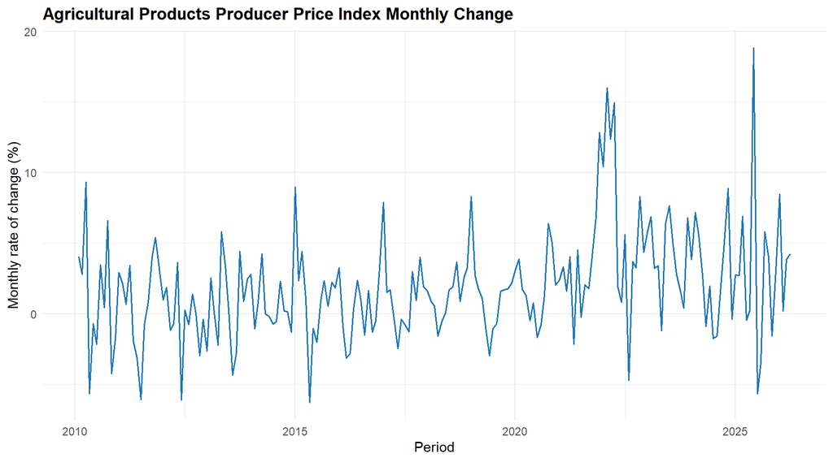

```r
actual_plot <- save_actual_series_plot(
  series,
  "outputs/figures/actual_series_plot.png"
)
actual_plot
```

```r
summary_stats <- data.frame(
  Mean = mean(series$value),
  Median = median(series$value),
  Minimum = min(series$value),
  Maximum = max(series$value),
  Standard_Deviation = stats::sd(series$value)
)
summary_stats
```

```
##       Mean Median Minimum Maximum Standard_Deviation
## 1 1.889846    1.7   -6.28   18.82           3.802344
```

```r
series$time_index <- seq_len(nrow(series))
trend_model_exploratory <- lm(value ~ time_index, data = series)
monthly_means <- series |>
  mutate(month = format(date, "%m")) |>
  group_by(month) |>
  summarise(mean_monthly_change = mean(value), .groups = "drop")

data.frame(
  Trend_Slope = coef(trend_model_exploratory)[["time_index"]],
  Trend_P_Value = summary(trend_model_exploratory)$coefficients["time_index", "Pr(>|t|)"]
)
```

```
##   Trend_Slope Trend_P_Value
## 1  0.02140983  5.987935e-06
```

```r
monthly_means
```

```
## # A tibble: 12 × 2
##    month mean_monthly_change
##    <chr>               <dbl>
##  1 01                  4.42
##  2 02                  3.31
##  3 03                  2.57
##  4 04                  2.45
##  5 05                 -0.664
##  6 06                  1.53
##  7 07                 -0.351
##  8 08                 -0.428
##  9 09                  1.99
## 10 10                  2.65
## 11 11                  2.32
## 12 12                  2.71
```

```r
data.frame(
  Highest_Average_Month = monthly_means$month[which.max(monthly_means$mean_monthly_change)],
  Highest_Average_Change = round(max(monthly_means$mean_monthly_change), 4),
  Lowest_Average_Month = monthly_means$month[which.min(monthly_means$mean_monthly_change)],
  Lowest_Average_Change = round(min(monthly_means$mean_monthly_change), 4)
)
```

```
##   Highest_Average_Month Highest_Average_Change Lowest_Average_Month
## 1                    01                 4.4156                   05
##   Lowest_Average_Change
## 1               -0.6638
```

The exploratory results indicate a volatile monthly percentage-change series with recurring monthly differences. The linear trend slope is small relative to the monthly variation, so methods that can handle seasonal movement and short-term volatility should be compared rather than selecting a trend-only model automatically.

# 7 Forecasting Setup

The last 24 monthly observations are used as a holdout period. Accuracy measures are calculated on the same holdout period for all applicable methods.

```r
forecast_results <- run_all_forecasts(series, holdout = 24)
forecast_data <- forecast_results$data
test_data <- forecast_data$test

data.frame(
  Training_Start = min(forecast_data$train$period),
  Training_End = max(forecast_data$train$period),
  Test_Start = min(test_data$period),
  Test_End = max(test_data$period),
  Holdout_Months = nrow(test_data)
)
```

```
##   Training_Start Training_End Test_Start Test_End Holdout_Months
## 1        2010-02      2024-04    2024-05  2026-04             24
```

# 8 Required Forecasting Methods

```r
accuracy_rows <- lapply(forecast_results$methods, function(method_result) {
  applicable <- if (is.null(method_result$applicable)) TRUE else method_result$applicable
  comparison_row(
    method_result$method,
    test_data$value,
    method_result$forecast,
    method_result$next_forecast,
    applicable = applicable,
    note = method_result$note
  )
})

accuracy_comparison <- bind_rows(accuracy_rows) |>
  mutate(across(where(is.numeric), ~ round(.x, 4)))

write.csv(
  accuracy_comparison,
  "outputs/tables/accuracy_comparison.csv",
  row.names = FALSE,
  fileEncoding = "UTF-8"
)

accuracy_comparison
```

```
##                                                Method    Bias    MAD     MSE
## 1                                   Naïve Forecasting  0.0646 5.4038 60.0475
## 2                                      Moving Average -0.3156 3.8337 27.3831
## 3                             Weighted Moving Average -0.0293 4.5765 37.9303
## 4                               Exponential Smoothing -1.7097 4.0303 27.0495
## 5                Trend-Adjusted Exponential Smoothing -1.6692 4.0096 26.8581
## 6                             Linear Trend Projection -1.8128 4.0795 27.1644
## 7                                    Seasonal Indices  0.8643 3.2207 23.4624
## 8                              Additive Decomposition -1.9982 4.0713 27.9789
## 9  Regression with Trend and Seasonal Dummy Variables -1.6921 3.8336 25.4955
## 10                       Multiplicative Decomposition      NA     NA      NA
##        MAPE     RSFE Tracking_Signal Next_Period_Forecast Applicable
## 1  455.7597   1.5500          0.2868               4.2600       TRUE
## 2  261.1904  -7.5742         -1.9757               3.1683       TRUE
## 3  353.4351  -0.7040         -0.1538               3.3270       TRUE
```

[output cut: 18 more lines]

```r
# Store the period-by-period forecast errors behind the aggregate accuracy measures.
forecast_errors <- bind_rows(lapply(
  forecast_results$methods,
  forecast_error_rows,
  test_data = test_data
)) |>
  mutate(across(where(is.numeric), ~ round(.x, 4)))

write.csv(
  forecast_errors,
  "outputs/tables/forecast_errors.csv",
  row.names = FALSE,
  fileEncoding = "UTF-8"
)

head(forecast_errors, 20)
```

```
##               Method  Period Actual Forecast Forecast_Error Applicable
## 1  Naïve Forecasting 2024-05  -0.91     2.71          -3.62       TRUE
## 2  Naïve Forecasting 2024-06   1.95    -0.91           2.86       TRUE
## 3  Naïve Forecasting 2024-07  -1.74     1.95          -3.69       TRUE
## 4  Naïve Forecasting 2024-08  -1.56    -1.74           0.18       TRUE
## 5  Naïve Forecasting 2024-09   2.00    -1.56           3.56       TRUE
## 6  Naïve Forecasting 2024-10   5.03     2.00           3.03       TRUE
## 7  Naïve Forecasting 2024-11   8.88     5.03           3.85       TRUE
## 8  Naïve Forecasting 2024-12  -0.39     8.88          -9.27       TRUE
## 9  Naïve Forecasting 2025-01   2.74    -0.39           3.13       TRUE
## 10 Naïve Forecasting 2025-02   2.70     2.74          -0.04       TRUE
## 11 Naïve Forecasting 2025-03   6.91     2.70           4.21       TRUE
## 12 Naïve Forecasting 2025-04  -0.45     6.91          -7.36       TRUE
## 13 Naïve Forecasting 2025-05   0.23    -0.45           0.68       TRUE
## 14 Naïve Forecasting 2025-06  18.82     0.23          18.59       TRUE
```

[output cut: 27 more lines]

## 8.1 Naïve Forecasting

The naïve method uses the most recent actual value as the one-step-ahead forecast.

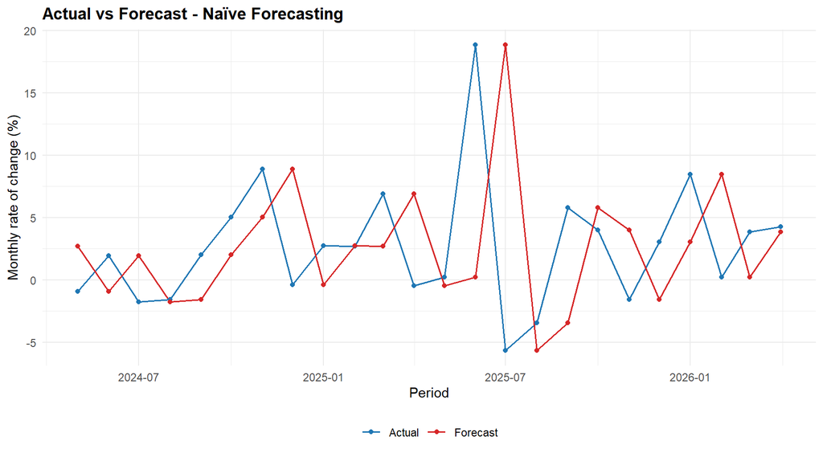

```r
method_lookup <- setNames(forecast_results$methods, vapply(forecast_results$methods, `[[`, character(1), "method"))
naive_result <- method_lookup[["Naïve Forecasting"]]
save_forecast_plot(test_data, naive_result$forecast, naive_result$method, "outputs/figures/naive_forecast_plot.png")
```

## 8.2 Moving Average

The moving average method tests 3-month, 6-month, and 12-month windows. The selected window minimizes holdout MAD.

```r
moving_average_result <- method_lookup[["Moving Average"]]
data.frame(
  Selected_Window_Months = moving_average_result$selected_window,
  Justification = moving_average_result$note
)
```

```
##   Selected_Window_Months
## 1                     12
##                                              Justification
## 1 Selected window: 12 months, based on lowest holdout MAD.
```

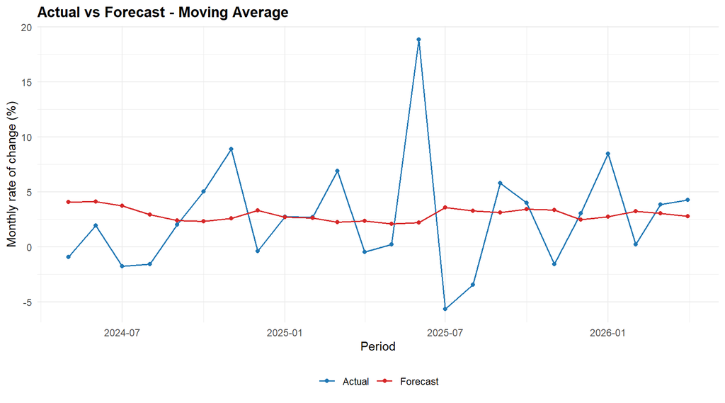

```r
save_forecast_plot(test_data, moving_average_result$forecast, moving_average_result$method, "outputs/figures/moving_average_plot.png")
```

## 8.3 Weighted Moving Average

Weights are assigned to the latest three observations, with more importance given to the most recent month.

```r
weighted_ma_result <- method_lookup[["Weighted Moving Average"]]
data.frame(
  Oldest_Weight = weighted_ma_result$weights[3],
  Middle_Weight = weighted_ma_result$weights[2],
  Most_Recent_Weight = weighted_ma_result$weights[1],
  Weighting_Logic = weighted_ma_result$note
)
```

```
##   Oldest_Weight Middle_Weight Most_Recent_Weight
## 1           0.2           0.3                0.5
##                                      Weighting_Logic
## 1 Weights favor recent observations: 0.5, 0.3, 0.2 .
```

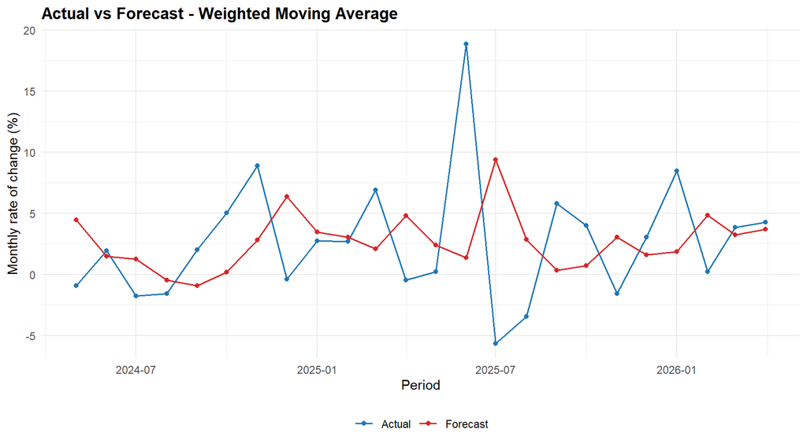

```r
save_forecast_plot(test_data, weighted_ma_result$forecast, weighted_ma_result$method, "outputs/figures/weighted_moving_average_plot.png")
```

## 8.4 Exponential Smoothing

Single exponential smoothing is estimated through `HoltWinters()` with a level component only.

```r
exponential_result <- method_lookup[["Exponential Smoothing"]]
data.frame(
  Level_Alpha = round(exponential_result$alpha, 4),
  Parameter_Explanation = exponential_result$note
)
```

```
##   Level_Alpha                                 Parameter_Explanation
## 1      0.1759 Level smoothing alpha estimated by HoltWinters: 0.176
```

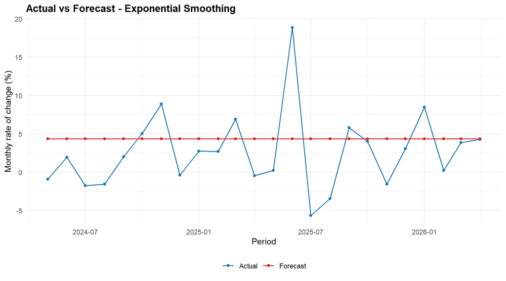

```r
save_forecast_plot(test_data, exponential_result$forecast, exponential_result$method, "outputs/figures/exponential_smoothing_plot.png")
```

## 8.5 Trend-Adjusted Exponential Smoothing

This method is considered because the series may contain medium-term movement even though monthly changes are volatile.

```r
trend_adjusted_result <- method_lookup[["Trend-Adjusted Exponential Smoothing"]]
data.frame(
  Level_Alpha = round(trend_adjusted_result$alpha, 4),
  Trend_Beta = round(trend_adjusted_result$beta, 4),
  Trend_Assessment = "The method is tested because the series has medium-term movement, but accuracy is compared against seasonal alternatives."
)
```

```
##       Level_Alpha Trend_Beta
## alpha      0.4809     0.0436
##                                                                                                                Trend_Assessment
## alpha The method is tested because the series has medium-term movement, but accuracy is compared against seasonal alternatives.
```

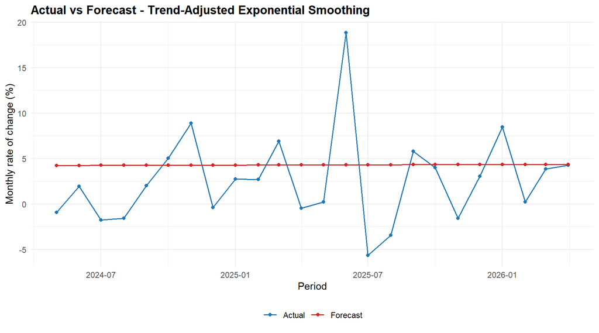

```r
save_forecast_plot(test_data, trend_adjusted_result$forecast, trend_adjusted_result$method, "outputs/figures/trend_adjusted_smoothing_plot.png")
```

## 8.6 Linear Trend Projection

The linear trend projection estimates a trend equation using a time index.

```r
linear_trend_result <- method_lookup[["Linear Trend Projection"]]
trend_coefficients <- coef(linear_trend_result$model)
data.frame(
  Trend_Equation = linear_trend_result$note,
  Intercept_Interpretation = paste("The intercept", round(trend_coefficients[1], 4), "is the fitted starting level when the time index is zero."),
  Slope_Interpretation = paste("The slope", round(trend_coefficients[2], 4), "is the average monthly change in percentage points implied by the linear trend.")
)
```

```
##                                  Trend_Equation
## 1 Trend equation: value = -0.5604 + 0.0273 * t.
##                                                          Intercept_Interpretation
## 1 The intercept -0.5604 is the fitted starting level when the time index is zero.
##                                                                               Slope_Interpretation
## 1 The slope 0.0273 is the average monthly change in percentage points implied by the linear trend.
```

```r
summary(linear_trend_result$model)
```

```
##
## Call:
## stats::lm(formula = value ~ t, data = train)
##
## Residuals:
##     Min      1Q  Median      3Q     Max
## -8.2787 -1.9579 -0.4062  1.5096 12.6049
##
## Coefficients:
##              Estimate Std. Error t value Pr(>|t|)
## (Intercept) -0.560359   0.515164  -1.088    0.278
## t            0.027279   0.005195   5.251 4.51e-07 ***
## ---
## Signif. codes:  0 '***' 0.001 '**' 0.01 '*' 0.05 '.' 0.1 ' ' 1
##
## Residual standard error: 3.354 on 169 degrees of freedom
## Multiple R-squared:  0.1403, Adjusted R-squared:  0.1352
## F-statistic: 27.57 on 1 and 169 DF,  p-value: 4.506e-07
```

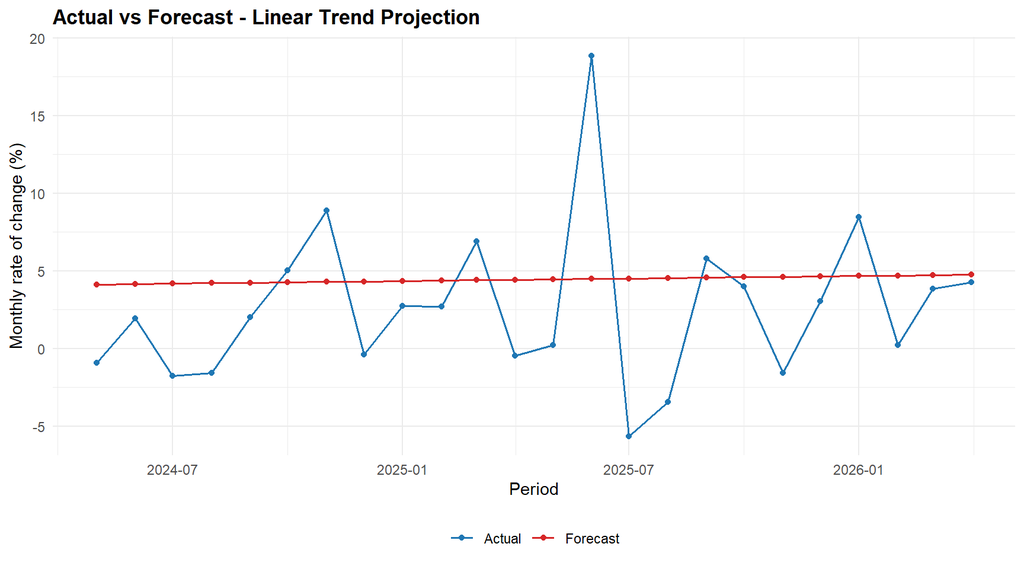

```r
save_forecast_plot(test_data, linear_trend_result$forecast, linear_trend_result$method, "outputs/figures/trend_projection_plot.png")
```

## 8.7 Seasonal Indices

The series is monthly, so 12 additive seasonal indices are estimated.

```r
seasonal_result <- method_lookup[["Seasonal Indices"]]
seasonal_result$seasonal_index
```

```
##    month seasonal_effect
## 1     01      2.46081454
## 2     02      1.77171930
## 3     03      0.41171930
## 4     04      0.74038596
## 5     05     -2.49561404
## 6     06     -1.51561404
## 7     07     -1.65847118
## 8     08     -1.91632832
## 9     09     -0.06847118
## 10    10      0.59581454
## 11    11      0.34510025
## 12    12      1.12010025
```

```r
data.frame(
  Number_of_Seasons = nrow(seasonal_result$seasonal_index),
  High_Season_Month = seasonal_result$seasonal_index$month[which.max(seasonal_result$seasonal_index$seasonal_effect)],
  High_Season_Index = round(max(seasonal_result$seasonal_index$seasonal_effect), 4),
  Low_Season_Month = seasonal_result$seasonal_index$month[which.min(seasonal_result$seasonal_index$seasonal_effect)],
  Low_Season_Index = round(min(seasonal_result$seasonal_index$seasonal_effect), 4)
)
```

```
##   Number_of_Seasons High_Season_Month High_Season_Index Low_Season_Month
## 1                12                01            2.4608               05
##   Low_Season_Index
## 1          -2.4956
```

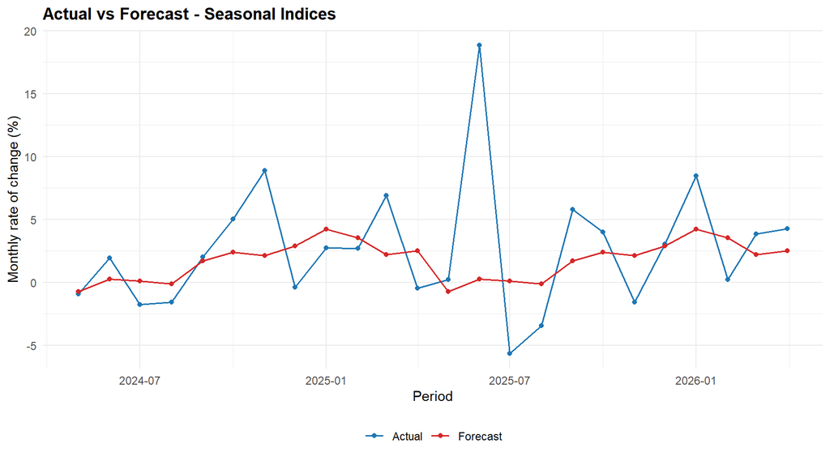

```r
save_forecast_plot(test_data, seasonal_result$forecast, seasonal_result$method, "outputs/figures/seasonal_indices_plot.png")
```

The seasonal index method is appropriate because the data are monthly and the same calendar months recur every year. The high-season and low-season months identify where monthly producer price changes tend to be above or below the average monthly change.

## 8.8 Additive Decomposition

Additive decomposition is suitable because the series is measured as monthly percentage change and contains negative values.

```r
additive_result <- method_lookup[["Additive Decomposition"]]
additive_components <- data.frame(
  Trend_Component_Mean = round(mean(additive_result$decomposition$trend, na.rm = TRUE), 4),
  Seasonal_Component_Min = round(min(additive_result$decomposition$seasonal, na.rm = TRUE), 4),
  Seasonal_Component_Max = round(max(additive_result$decomposition$seasonal, na.rm = TRUE), 4),
  Residual_Component_SD = round(sd(additive_result$decomposition$random, na.rm = TRUE), 4)
)
additive_components
```

```
##   Trend_Component_Mean Seasonal_Component_Min Seasonal_Component_Max
## 1               1.6892                  -2.04                 2.6064
##   Residual_Component_SD
## 1                2.6888
```

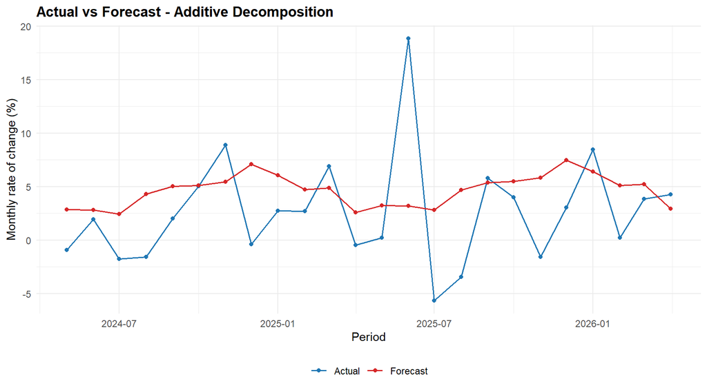

```r
save_forecast_plot(test_data, additive_result$forecast, additive_result$method, "outputs/figures/additive_decomposition_plot.png")
```

## 8.9 Multiplicative Decomposition

Multiplicative decomposition is not suitable because the monthly rate-of-change series contains negative values. Multiplicative decomposition requires strictly positive values.

```r
method_lookup[["Multiplicative Decomposition"]]$note
```

```
## [1] "Not applicable because the monthly rate-of-change series contains negative values; multiplicative decomposition requires strictly positive values."
```

## 8.10 Regression with Trend and Seasonal Dummy Variables

This regression uses a time trend and monthly seasonal dummy variables.

```r
regression_result <- method_lookup[["Regression with Trend and Seasonal Dummy Variables"]]
regression_coefficients <- as.data.frame(summary(regression_result$model)$coefficients)
regression_coefficients$Term <- rownames(regression_coefficients)
rownames(regression_coefficients) <- NULL
regression_coefficients[, c("Term", "Estimate", "Std. Error", "t value", "Pr(>|t|)")]
```

```
##           Term    Estimate  Std. Error   t value     Pr(>|t|)
## 1  (Intercept)  1.88664935 0.943961701  1.998650 4.736138e-02
## 2            t  0.02621977 0.004855215  5.400331 2.401025e-07
## 3      month02 -0.55799639 1.163682735 -0.479509 6.322396e-01
## 4      month03 -1.94421616 1.163591573 -1.670875 9.672597e-02
## 5      month04 -1.64176926 1.163520665 -1.411036 1.602001e-01
## 6      month05 -4.74667042 1.183955922 -4.009161 9.371104e-05
## 7      month06 -3.79289019 1.183806584 -3.203978 1.639808e-03
## 8      month07 -3.96196710 1.183677142 -3.347169 1.020414e-03
## 9      month08 -4.24604401 1.183567604 -3.587496 4.447954e-04
## 10     month09 -2.42440664 1.183477974 -2.048544 4.216143e-02
## 11     month10 -1.78634069 1.183408257 -1.509488 1.331713e-01
## 12     month11 -2.06327475 1.183358457 -1.743575 8.317824e-02
## 13     month12 -1.31449452 1.183328576 -1.110845 2.683227e-01
```

```r
data.frame(
  Trend_Coefficient_Interpretation = "The time-trend coefficient measures the fitted average monthly change after controlling for month effects.",
  Seasonal_Dummy_Interpretation = "Each monthly dummy coefficient measures that month's average difference from the reference month, holding the time trend constant."
)
```

```
##                                                                             Trend_Coefficient_Interpretation
## 1 The time-trend coefficient measures the fitted average monthly change after controlling for month effects.
##                                                                                                        Seasonal_Dummy_Interpretation
## 1 Each monthly dummy coefficient measures that month's average difference from the reference month, holding the time trend constant.
```

```r
summary(regression_result$model)
```

```
##
## Call:
## stats::lm(formula = value ~ t + month, data = train)
##
## Residuals:
##     Min      1Q  Median      3Q     Max
## -6.3198 -1.8244 -0.5881  1.2918 10.8695
##
## Coefficients:
##              Estimate Std. Error t value Pr(>|t|)
## (Intercept)  1.886649   0.943962   1.999 0.047361 *
## t            0.026220   0.004855   5.400 2.40e-07 ***
## month02     -0.557996   1.163683  -0.480 0.632240
## month03     -1.944216   1.163592  -1.671 0.096726 .
## month04     -1.641769   1.163521  -1.411 0.160200
## month05     -4.746670   1.183956  -4.009 9.37e-05 ***
## month06     -3.792890   1.183807  -3.204 0.001640 **
## month07     -3.961967   1.183677  -3.347 0.001020 **
## month08     -4.246044   1.183568  -3.587 0.000445 ***
## month09     -2.424407   1.183478  -2.049 0.042161 *
## month10     -1.786341   1.183408  -1.509 0.133171
## month11     -2.063275   1.183358  -1.744 0.083178 .
## month12     -1.314495   1.183329  -1.111 0.268323
## ---
## Signif. codes:  0 '***' 0.001 '**' 0.01 '*' 0.05 '.' 0.1 ' ' 1
##
## Residual standard error: 3.131 on 158 degrees of freedom
## Multiple R-squared:  0.2995, Adjusted R-squared:  0.2463
## F-statistic: 5.628 on 12 and 158 DF,  p-value: 5.327e-08
```

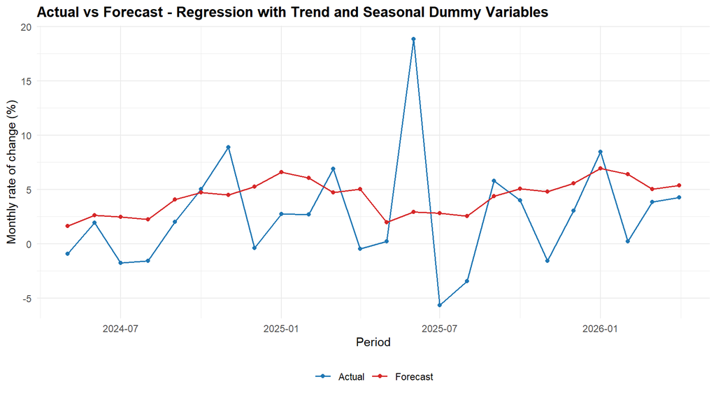

```r
save_forecast_plot(test_data, regression_result$forecast, regression_result$method, "outputs/figures/regression_seasonal_dummy_plot.png")
```

# 9 Superior Method Selection

```r
eligible_methods <- accuracy_comparison |>
  filter(Applicable) |>
  arrange(MAPE, MAD, abs(Tracking_Signal))

superior_method_name <- eligible_methods$Method[1]
superior_accuracy <- eligible_methods[1, ]
superior_result <- method_lookup[[superior_method_name]]
superior_forecast <- superior_result$next_forecast

final_forecast <- data.frame(
  Selected_Superior_Method = superior_method_name,
  Data_Access_Date = source_info$access_date,
  Latest_Available_Observation = latest_observation,
  Forecast_Target_Period = forecast_target_period,
  Forecasted_Value = round(superior_forecast, 4),
  Bias = round(superior_accuracy$Bias, 4),
  MAD = round(superior_accuracy$MAD, 4),
  MSE = round(superior_accuracy$MSE, 4),
  MAPE = round(superior_accuracy$MAPE, 4),
  RSFE = round(superior_accuracy$RSFE, 4),
  Tracking_Signal = round(superior_accuracy$Tracking_Signal, 4),
  Interpretation = paste(
    "The selected method forecasts the monthly rate of change in the Agricultural Products Producer Price Index for",
    forecast_target_period,
    "as",
    round(superior_forecast, 4),
    "percent."
  )
)

write.csv(
  final_forecast,
  "outputs/tables/final_forecast.csv",
  row.names = FALSE,
  fileEncoding = "UTF-8"
)

writexl::write_xlsx(
  list(
    accuracy_comparison = accuracy_comparison,
    forecast_errors = forecast_errors,
    final_forecast = final_forecast
  ),
  "outputs/tables/forecast_results.xlsx"
)

final_forecast
```

```
##   Selected_Superior_Method Data_Access_Date Latest_Available_Observation
## 1         Seasonal Indices       2026-05-29                      2026-04
##   Forecast_Target_Period Forecasted_Value   Bias    MAD     MSE    MAPE   RSFE
## 1                2026-05          -0.6638 0.8643 3.2207 23.4624 204.033 20.743
##   Tracking_Signal
## 1          6.4406
##                                                                                                                               Interpretation
## 1 The selected method forecasts the monthly rate of change in the Agricultural Products Producer Price Index for 2026-05 as -0.6638 percent.
```

The superior method is selected from applicable methods using holdout MAPE and MAD, while also checking whether the method is structurally reasonable for a monthly series with seasonality and volatile percentage changes. The chosen method is therefore based on both quantitative accuracy and suitability to the data structure.

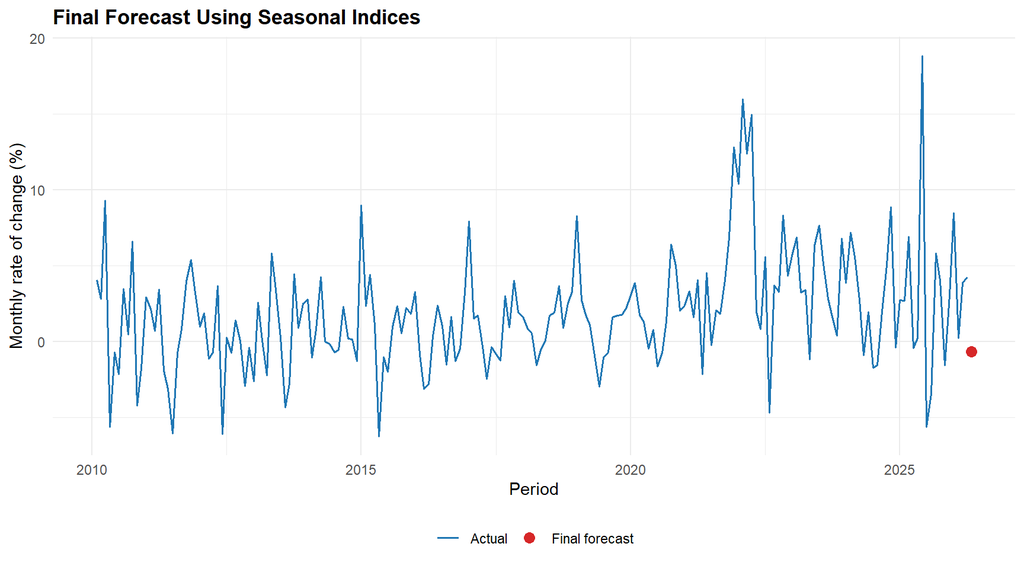

```r
save_superior_plot(
  series,
  forecast_target_period,
  superior_forecast,
  superior_method_name,
  "outputs/figures/superior_method_plot.png"
)
```

# 10 Interpretation of Results

The selected TÜİK variable represents the monthly percentage change in the Agricultural Products Producer Price Index. This variable is suitable for forecasting because it is numeric, regularly observed at monthly frequency, and available over a long ordered time span from 2010-02 to 2026-04.

The exploratory analysis shows volatile monthly changes with recurring month-level differences. Seasonal Indices performs better than the competing methods in the holdout comparison, while trend-only and decomposition-based alternatives produce larger aggregate errors or stronger tracking-signal imbalance. The final forecast of -0.6638 percent for 2026-05 means that the selected method expects a small negative monthly change in the index for the next period after the latest available TÜİK observation.

# 11 Limitations

The series measures monthly percentage change, which can be volatile and negative. This makes multiplicative decomposition unsuitable. The model comparison is based on a 24-month holdout window, so the results may change after later TÜİK revisions or unusual economic shocks. The notebook uses the live TÜİK dataflow verified through `tuikr::statistical_tables()`, but the SDMX download helper `tuikr::statistical_data()` returned HTTP 401 in the local environment, so the verified dataflow is accessed through the TÜİK Data Browser JSON endpoint in reproducible R code. This fallback still satisfies the course-approved requirement that data access must happen inside R without manual download or manually prepared data files.

# 12 Reproducibility Notes

Run the notebook from the project root. The script creates the required `outputs/tables` and `outputs/figures` folders automatically and does not use any manually downloaded data file.